# Cancer Incidences in the U.S.

## Lele Zhao

### Final Project for CMPS 3160

# Introduction

In this project, I aim to investigate cancer incidence rates in the United States. My research inquiry centers on discerning cancer incidence variations concerning gender, age, and race across years.

# Data Extraction, Transform, and Load (ETL)

```python
#Load libraries needed
import pandas as pd
import numpy as np
import matplotlib.pyplot as plt
```

```python
#I've placed the data I obtained from the Centers for Disease Control and Prevention (CDC) into the Data folder of my github
!git clone https://github.com/LeleZW/Data_CMPS3160.git
!ls Data
```

```
Cloning into 'Data_CMPS3160'...
remote: Enumerating objects: 3, done.
remote: Counting objects: 100% (3/3), done.
remote: Compressing objects: 100% (3/3), done.
remote: Total 3 (delta 0), reused 0 (delta 0), pack-reused 0
Receiving objects: 100% (3/3), 118.86 KiB | 2.90 MiB/s, done.
'United States and Puerto Rico Cancer Statistics, 1999-2020 Incidence.txt'
```

```python
#Now, read the .txt data using pd.read_csv.
df = pd.read_csv('Data_CMPS3160/United States and Puerto Rico Cancer Statistics, 1999-2020 Incidence.txt', sep='\t')
display(df.head())
```

|  | Notes | Leading Cancer Sites | Leading Cancer Sites Code | Year | Year Code | Age Groups | Age Groups Code | Sex | Sex Code | Race | Race Code | Count |
| --- | --- | --- | --- | --- | --- | --- | --- | --- | --- | --- | --- | --- |
| 0 | NaN | Brain and Other Nervous System | 31010-31040 | 2010.0 | 2010.0 | < 1 year | 1 | Female | F | White | 2106-3 | 47.0 |
| 1 | NaN | Brain and Other Nervous System | 31010-31040 | 2010.0 | 2010.0 | < 1 year | 1 | Male | M | White | 2106-3 | 67.0 |
| 2 | NaN | Brain and Other Nervous System | 31010-31040 | 2010.0 | 2010.0 | 1-4 years | 1-4 | Female | F | Black or African American | 2054-5 | 47.0 |
| 3 | NaN | Brain and Other Nervous System | 31010-31040 | 2010.0 | 2010.0 | 1-4 years | 1-4 | Female | F | White | 2106-3 | 311.0 |
| 4 | NaN | Brain and Other Nervous System | 31010-31040 | 2010.0 | 2010.0 | 1-4 years | 1-4 | Male | M | Asian or Pacific Islander | A-PI | 16.0 |

Several redundant columns exist in the data frame, and I will remove these columns in the subsequent code.

```python
#Display the column names
df.columns.values
```

```
array(['Notes', 'Leading Cancer Sites', 'Leading Cancer Sites Code',
       'Year', 'Year Code', 'Age Groups', 'Age Groups Code', 'Sex',
       'Sex Code', 'Race', 'Race Code', 'Count'], dtype=object)
```

```python
#Removing unwanted columns
df2 = df[['Leading Cancer Sites', 'Year', 'Age Groups', 'Sex', 'Race', 'Count']]
display(df2.head())
```

|  | Leading Cancer Sites | Year | Age Groups | Sex | Race | Count |
| --- | --- | --- | --- | --- | --- | --- |
| 0 | Brain and Other Nervous System | 2010.0 | < 1 year | Female | White | 47.0 |
| 1 | Brain and Other Nervous System | 2010.0 | < 1 year | Male | White | 67.0 |
| 2 | Brain and Other Nervous System | 2010.0 | 1-4 years | Female | Black or African American | 47.0 |
| 3 | Brain and Other Nervous System | 2010.0 | 1-4 years | Female | White | 311.0 |
| 4 | Brain and Other Nervous System | 2010.0 | 1-4 years | Male | Asian or Pacific Islander | 16.0 |

Since there are spaces in the variable name, it's advisable to eliminate them.

```python
#Renaming columns
df2 = df2.rename(columns={'Leading Cancer Sites':'LeadingCancerSites', 'Age Groups': 'AgeGroups'})
display(df2.head())
```

|  | LeadingCancerSites | Year | AgeGroups | Sex | Race | Count |
| --- | --- | --- | --- | --- | --- | --- |
| 0 | Brain and Other Nervous System | 2010.0 | < 1 year | Female | White | 47.0 |
| 1 | Brain and Other Nervous System | 2010.0 | < 1 year | Male | White | 67.0 |
| 2 | Brain and Other Nervous System | 2010.0 | 1-4 years | Female | Black or African American | 47.0 |
| 3 | Brain and Other Nervous System | 2010.0 | 1-4 years | Female | White | 311.0 |
| 4 | Brain and Other Nervous System | 2010.0 | 1-4 years | Male | Asian or Pacific Islander | 16.0 |

```python
#Change the float to int for Year and Count
df2.dtypes
df2.Year = np.int_(df2.Year)
df2.Count = np.int_(df2.Count)
display(df2.head())
```

|  | LeadingCancerSites | Year | AgeGroups | Sex | Race | Count |
| --- | --- | --- | --- | --- | --- | --- |
| 0 | Brain and Other Nervous System | 2010 | < 1 year | Female | White | 47 |
| 1 | Brain and Other Nervous System | 2010 | < 1 year | Male | White | 67 |
| 2 | Brain and Other Nervous System | 2010 | 1-4 years | Female | Black or African American | 47 |
| 3 | Brain and Other Nervous System | 2010 | 1-4 years | Female | White | 311 |
| 4 | Brain and Other Nervous System | 2010 | 1-4 years | Male | Asian or Pacific Islander | 16 |

```python
df2.LeadingCancerSites
```

```
0        Brain and Other Nervous System
1        Brain and Other Nervous System
2        Brain and Other Nervous System
3        Brain and Other Nervous System
4        Brain and Other Nervous System
                      ...
20177                               NaN
20178                               NaN
20179                               NaN
20180                               NaN
20181                               NaN
Name: LeadingCancerSites, Length: 20182, dtype: object
```

As observed, there are NaNs in the "Cancersites" variable. Our initial step is to remove these NaN values.

```python
df3 = df2.dropna(subset=['LeadingCancerSites'])
df3.LeadingCancerSites
```

```
0               Brain and Other Nervous System
1               Brain and Other Nervous System
2               Brain and Other Nervous System
3               Brain and Other Nervous System
4               Brain and Other Nervous System
                         ...
20120    Urinary Bladder, invasive and in situ
20121    Urinary Bladder, invasive and in situ
20122    Urinary Bladder, invasive and in situ
20123    Urinary Bladder, invasive and in situ
20124    Urinary Bladder, invasive and in situ
Name: LeadingCancerSites, Length: 20125, dtype: object
```

# Summary Statistics

First, we can look at all cancer incidences. I want to examine the trend in the number of cancer incidences.

```python
#Using group_by to look at the trend
df3.groupby('Year').Count.sum()
```

```
Year
2010    1418026
2011    1451296
2012    1439151
2013    1467214
2014    1491358
2015    1530722
2016    1552257
2017    1580765
2018    1598161
2019    1635412
2020    1434863
Name: Count, dtype: int64
```

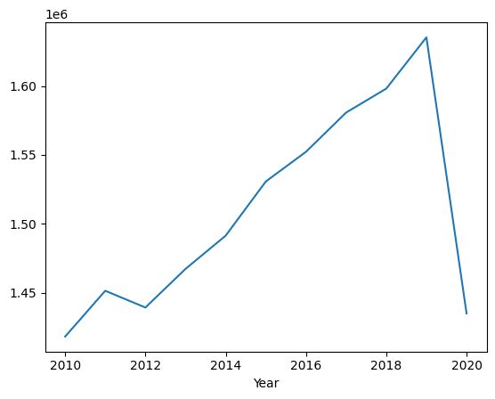

```python
#Draw the plot across time
df3.groupby('Year').Count.sum().plot.line()
```

Cancer incidence steadily increased between 2012 and 2019, reaching its peak in 2019 with 1,635,412 reported cases. Notably, there was a significant decline in 2020, which raises an interesting point. It's possible that some individuals who had cancer also contracted COVID-19, and when they passed away, their deaths may have been attributed to COVID-19.

Now, look at the most frequent cancer type.

```python
df3.groupby('LeadingCancerSites').Count.sum()
```

```
LeadingCancerSites
Brain and Other Nervous System            244873
Breast                                   2704574
Cervix Uteri                              138412
Colon and Rectum                         1553202
Corpus Uteri                              576504
Esophagus                                 189060
Gallbladder                                41940
Kidney and Renal Pelvis                   683675
Larynx                                    133930
Leukemias                                 565146
Liver                                     300759
Lung and Bronchus                        2417770
Melanoma of the Skin                      867723
Myeloma                                   283708
Non-Hodgkin Lymphoma                      768452
Oral Cavity and Pharynx                   489264
Ovary                                     230065
Pancreas                                  534724
Prostate                                 2289291
Stomach                                   258955
Thyroid                                   509501
Urinary Bladder, invasive and in situ     817697
Name: Count, dtype: int64
```

```python
df3.groupby('LeadingCancerSites').Count.sum().max() / df3.Count.sum()
```

```
0.16293375142514183
```

Breast cancer is the most prevalent cancer, with 2,704,574 cases reported from 2010 to 2020, comprising 16.29% of all incidences.

I am interested in whether the most frequent cancers differ in gender.

```python
# survivors_cube = titanic_df.pivot_table(
    # index="sex", columns=["adult", "pclass"],
    # values="survived", aggfunc=np.mean)
df3_cube_sex = df3.pivot_table(
    index = 'LeadingCancerSites', columns = ['Sex'],
    values = 'Count', aggfunc = np.sum
)
df3_cube_sex
```

| Sex LeadingCancerSites | Female | Male |
| --- | --- | --- |
| Brain and Other Nervous System | 107946.0 | 136927.0 |
| Breast | 2682390.0 | 22184.0 |
| Cervix Uteri | 138412.0 | NaN |
| Colon and Rectum | 737563.0 | 815639.0 |
| Corpus Uteri | 576504.0 | NaN |
| Esophagus | 38827.0 | 150233.0 |
| Gallbladder | 28996.0 | 12944.0 |
| Kidney and Renal Pelvis | 250145.0 | 433530.0 |
| Larynx | 26909.0 | 107021.0 |
| Leukemias | 235663.0 | 329483.0 |
| Liver | 74294.0 | 226465.0 |
| Lung and Bronchus | 1159884.0 | 1257886.0 |
| Melanoma of the Skin | 355369.0 | 512354.0 |
| Myeloma | 125646.0 | 158062.0 |
| Non-Hodgkin Lymphoma | 346108.0 | 422344.0 |
| Oral Cavity and Pharynx | 139692.0 | 349572.0 |
| Ovary | 230065.0 | NaN |
| Pancreas | 258873.0 | 275851.0 |
| Prostate | NaN | 2289291.0 |
| Stomach | 98742.0 | 160213.0 |
| Thyroid | 380335.0 | 129166.0 |
| Urinary Bladder, invasive and in situ | 193843.0 | 623854.0 |

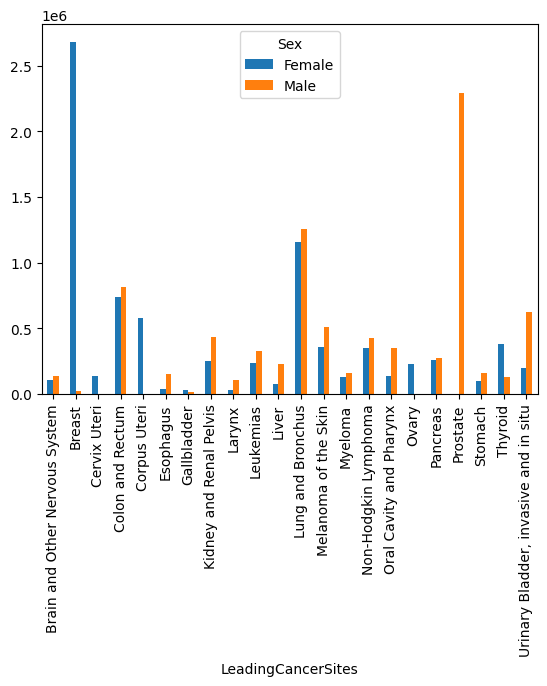

```python
df3_cube_sex.plot.bar()
```

Breast cancer predominantly affects women. However, in common diseases that affect both men and women, men tend to have more cases than women.